# 描述性统计

# 数据准备

```r
rm(list = ls())
nba = read.csv("NBA.csv")
head(nba)
```

```
##        球员姓名     位置 身高 体重 年龄 球龄 上场次数 场均时间 进攻能力
## 1   斯蒂芬-库里 得分后卫 1.91   86   29    7       79    33.38   31.933
## 2 勒布朗-詹姆斯   大前锋 2.03  113   32   13       74    37.75   36.140
## 3 保罗-米尔萨普     中锋 2.03  112   32   10       69    33.95   22.712
## 4   戈登-海沃德   小前锋 2.03  103   27    6       73    34.45   25.382
## 5 布雷克-格里芬     中锋 2.08  114   28    6       61    34.03   27.488
## 6     凯尔-洛里 控球后卫 1.85   89   31   10       60    37.40   29.350
##   防守能力 是否入选过全明星 球队胜率 球队市值 球员薪金
## 1        4               是       高       高     3468
## 2        8               是       高       中     3329
## 3        7               是       高       低     3127
## 4        5               是       高       中     2973
## 5        6               是       高       高     2951
## 6        4               是       高       中     2870
```

```r
par(family = 'STKaiti')
```

样本共有397个，变量包括球员姓名、位置、身高、体重、年龄、球龄、上场次数、场均时间、进攻能力、防守能力、是否入选过全明星、球队胜率、球队市值、球员薪金。

## 单变量

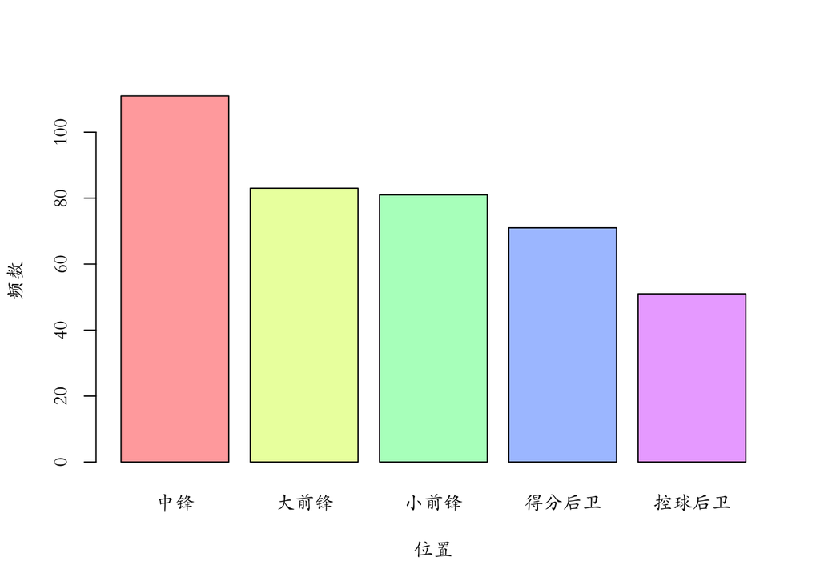

```r
par(family = 'STKaiti')
## 定性变量--柱状图 ##
a = table(nba$位置)
a = a[order(a, decreasing = T)]
barplot(a[1:5], names.arg = names(a)[1:5], col = rainbow(5, alpha = 0.4), xlab = "位置", ylab="频数")
```

总体样本个数为397个，其中样本量最多的位置是中锋，有111个样本数据。其次是大前锋球员的样本量，有83个。小前锋样本量接近大前锋样本量，有81个。得分后卫和控球后卫的样本量较小，其中得分后卫有71个样本，控球后卫有51个样本。造成样本中不同位置的样本量的差异的原因可能有以下几点： + 因为nba大部分后卫球员都具有得分能力导致得分后卫和控球后卫的界限模糊，使得分后卫和控球后卫的样本量相差加大 + 因为中锋具有盖帽、篮板、进攻等作用，在篮球中位置较为重要。且因为篮下对抗的需要，中锋的体力消耗较其他位置球员快，所以球队中往往会有多名中锋球员。因此中锋的样本量是最多的。 + 因为大前锋和小前锋的职责不一致，所以球队需要大前锋和小前锋的数量较为一致。 + 由于篮球得分大多数都是通过突破、单打、中投以及补篮，因而具有进攻特性的球员比后卫这类防守特性的球员在战术更重要，因此导致NBA球员中位置的球员人员不是均匀分布，而是按中锋、大前、小前、得分、控球的顺序依次递减。

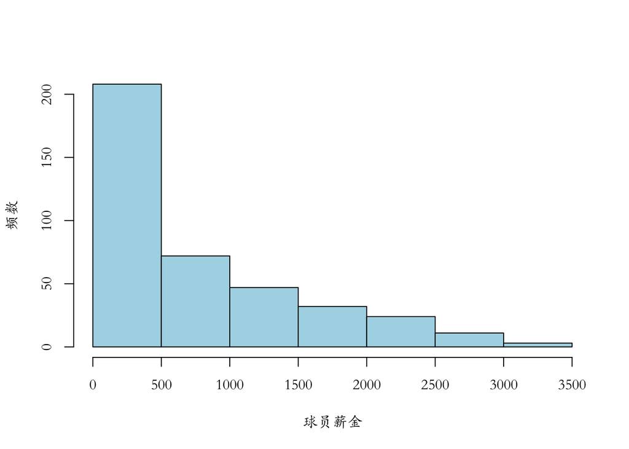

```r
## 定量变量--直方图 ##
par(family = 'STKaiti')
chara = sort(nba$球员薪金)[1:1500] # 去掉异常值
hist(chara, breaks = 10, xlab = "球员薪金", ylab = "频数", main = "", col = "lightblue")
```

如左图所示，球员的薪金随着薪金的数量增多而快速下降。在397个样本中，薪金最低的球员仅7万美金；而薪金最高的球员——斯蒂芬-库里却有高达3468万美元的薪金。其中有50%的球员薪金在0到500万美金的有208人，在500-1000万美金的有72人，在1000-1500万美金的有47人，在1500-2000万美金的有32人，在2000-25000万美金的有24人，在2500-3000万美金的有11人，在3000万美金以上仅有3人，分别是斯蒂芬-库里、勒布朗-詹姆斯、保罗-米尔萨普。说明NBA球员的薪金存在较大的差异，明星球员的薪金均值在782.4万美元，但是有245位球员的薪金在均值之下，即38.3%的球员占了50%的薪酬。

## 多变量

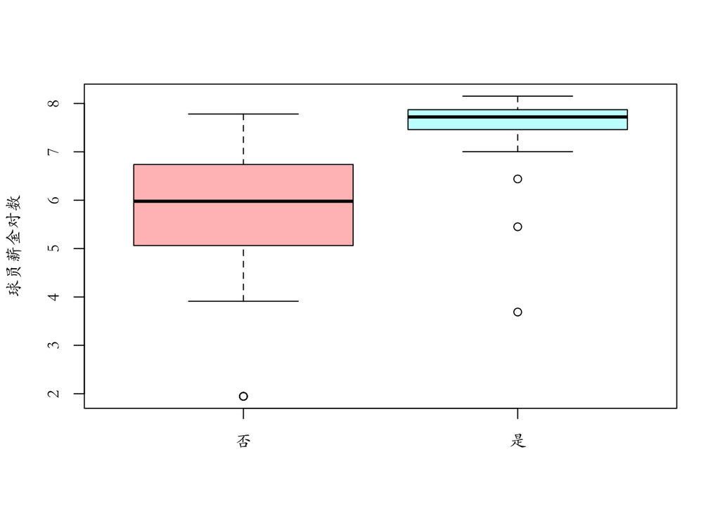

```r
par(family = 'STKaiti')
## 定性与定量变量--分组箱线图 ##
boxplot(log(nba$球员薪金)~是否入选过全明星, data = nba, col = rainbow(2, alpha = 0.3), ylab = "球员薪金对数")
```

如箱线图所示，有349名球员没有入选过全明星，48位球员入选过全明星。其中未入选球员的薪金中位数对数比入选球员的薪金中位数低，说明入选过全明星的球员比未入选过全明星的球员更受球队的青睐，球队交易金额更高。同时，通过箱线图还发现，入选过全明星的球员薪金除极个别球员外均比75%的未入选全明星的球员薪金高，且入选过全明星的球员薪金中位数基本与未入选过全明星的球员薪金极大值持平。因此，对于球员而言，是否入选全明星较大程度影响其薪金的议价能力。而个别入选全明星薪金却异常的球员可能是因为合同签订时未入选全明星但入选全明星后合同约定薪金仍有效，这些球员在合同到期后薪金水平可预期地会大幅上涨。

```r
# 定量与定量之间--散点图矩阵
par(family = 'STKaiti')
student = read.csv('student.csv')
head(student)
```

```
##   Y1  Y2 Y3 Y4 Y5 Y6
## 1 65  61 72 84 81 79
## 2 77  77 76 64 70 55
## 3 67  63 49 65 67 57
## 4 78  84 75 62 71 64
## 5 66  71 67 52 65 57
## 6 83 100 79 41 67 50
```

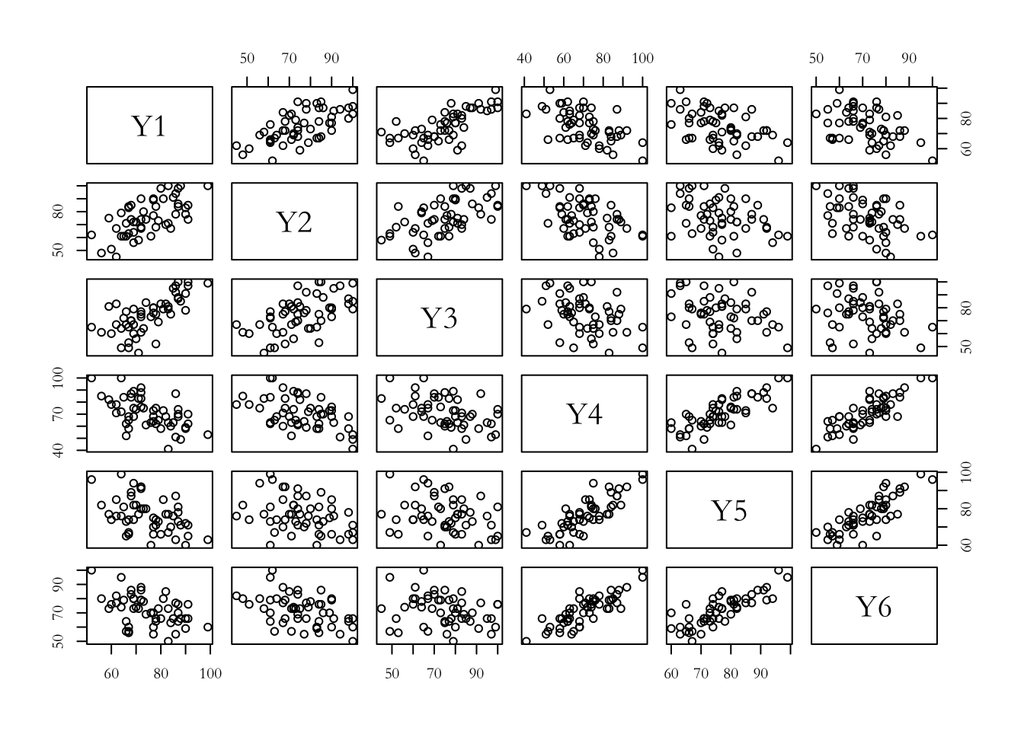

```r
pairs(student)
```

样本是某学生群体的成绩，样本容量为52,变量包括Y1、Y2、Y3、Y4、Y5、Y6六个学科的成绩。

由散点图矩阵可知，学科成绩Y1、Y2、Y3彼此之间存在明显的正线性相关关系；而学科成绩Y4、Y5、Y6彼此之间也存在明显的正线性相关关系。且Y1、Y2、Y3与Y4、Y5、Y6之间，两两不存在明显的线性相关关系。说明影响学生Y1、Y2、Y3学科成绩的主因素和影响Y1、Y2、Y3学科成绩的主因素不是同一种学生因素。即存在两种知识水平或能力对Y1、Y2、Y3与Y4、Y5、Y6起到较大的影响。